# step-1 Business problem understanding

- Analytical report

```python
import numpy as np
import pandas as pd
import matplotlib.pyplot as plt
import seaborn as sns
```

```python
df = pd.read_csv("LoanData.csv")
df
```

|  | Loan_ID | Gender | Married | Dependents | Education | Self_Employed | ApplicantIncome | CoapplicantIncome | LoanAmount | Loan_Amount_Term | Credit_History | Property_Area | Loan_Status |
| --- | --- | --- | --- | --- | --- | --- | --- | --- | --- | --- | --- | --- | --- |
| 0 | LP001002 | Male | No | 0 | Graduate | No | 5849 | 0.0 | NaN | 360.0 | 1.0 | Urban | Y |
| 1 | LP001003 | Male | Yes | 1 | Graduate | No | 4583 | 1508.0 | 128.0 | 360.0 | 1.0 | Rural | N |
| 2 | LP001005 | Male | Yes | 0 | Graduate | Yes | 3000 | 0.0 | 66.0 | 360.0 | 1.0 | Urban | Y |
| 3 | LP001006 | Male | Yes | 0 | Not Graduate | No | 2583 | 2358.0 | 120.0 | 360.0 | 1.0 | Urban | Y |
| 4 | LP001008 | Male | No | 0 | Graduate | No | 6000 | 0.0 | 141.0 | 360.0 | 1.0 | Urban | Y |
| ... | ... | ... | ... | ... | ... | ... | ... | ... | ... | ... | ... | ... | ... |
| 609 | LP002978 | Female | No | 0 | Graduate | No | 2900 | 0.0 | 71.0 | 360.0 | 1.0 | Rural | Y |
| 610 | LP002979 | Male | Yes | 3+ | Graduate | No | 4106 | 0.0 | 40.0 | 180.0 | 1.0 | Rural | Y |
| 611 | LP002983 | Male | Yes | 1 | Graduate | No | 8072 | 240.0 | 253.0 | 360.0 | 1.0 | Urban | Y |
| 612 | LP002984 | Male | Yes | 2 | Graduate | No | 7583 | 0.0 | 187.0 | 360.0 | 1.0 | Urban | Y |
| 613 | LP002990 | Female | No | 0 | Graduate | Yes | 4583 | 0.0 | 133.0 | 360.0 | 0.0 | Semiurban | N |

614 rows × 13 columns

# Data Exploration

```python
df.shape
```

```
(614, 13)
```

```python
df.columns.tolist()
```

```
['Loan_ID',
 'Gender',
 'Married',
 'Dependents',
 'Education',
 'Self_Employed',
 'ApplicantIncome',
 'CoapplicantIncome',
 'LoanAmount',
 'Loan_Amount_Term',
 'Credit_History',
 'Property_Area',
 'Loan_Status']
```

```python
df.info()
```

```
<class 'pandas.core.frame.DataFrame'>
RangeIndex: 614 entries, 0 to 613
Data columns (total 13 columns):
 #   Column             Non-Null Count  Dtype
---  ------             --------------  -----
 0   Loan_ID            614 non-null    object
 1   Gender             601 non-null    object
 2   Married            611 non-null    object
 3   Dependents         599 non-null    object
 4   Education          614 non-null    object
 5   Self_Employed      582 non-null    object
 6   ApplicantIncome    614 non-null    int64
 7   CoapplicantIncome  614 non-null    float64
 8   LoanAmount         592 non-null    float64
 9   Loan_Amount_Term   600 non-null    float64
 10  Credit_History     564 non-null    float64
 11  Property_Area      614 non-null    object
 12  Loan_Status        614 non-null    object
dtypes: float64(4), int64(1), object(8)
memory usage: 62.5+ KB
```

**value_counts() are applicable on discrete or count**

```python
# Discrete

df["Gender"].unique()  # This is correct data type
```

```
array(['Male', 'Female', nan], dtype=object)
```

```python
df["Gender"].value_counts()
```

```
Gender
Male      489
Female    112
Name: count, dtype: int64
```

```python
# Discrete

df["Married"].unique()  # This is correct data type
```

```
array(['No', 'Yes', nan], dtype=object)
```

```python
df["Married"].value_counts()
```

```
Married
Yes    398
No     213
Name: count, dtype: int64
```

```python
# Discrete Count

df["Dependents"].unique() # This is wrong data type because of wrong value
```

```
array(['0', '1', '2', '3+', nan], dtype=object)
```

```python
# Dependents is Discrete count thats why we use value_counts()

df["Dependents"].value_counts()
```

```
Dependents
0     345
1     102
2     101
3+     51
Name: count, dtype: int64
```

```python
# Discrete

df["Education"].unique()  # This is correct data type
```

```
array(['Graduate', 'Not Graduate'], dtype=object)
```

```python
df["Education"].value_counts()
```

```
Education
Graduate        480
Not Graduate    134
Name: count, dtype: int64
```

```python
# Discrete

df["Self_Employed"].unique()  # This is correct data type
```

```
array(['No', 'Yes', nan], dtype=object)
```

```python
df["Self_Employed"].value_counts()
```

```
Self_Employed
No     500
Yes     82
Name: count, dtype: int64
```

```python
# Continous

df["ApplicantIncome"].unique()  # This is correct data Type
```

```
array([ 5849,  4583,  3000,  2583,  6000,  5417,  2333,  3036,  4006,
       12841,  3200,  2500,  3073,  1853,  1299,  4950,  3596,  3510,
        4887,  2600,  7660,  5955,  3365,  3717,  9560,  2799,  4226,
        1442,  3750,  4166,  3167,  4692,  3500, 12500,  2275,  1828,
        3667,  3748,  3600,  1800,  2400,  3941,  4695,  3410,  5649,
        5821,  2645,  4000,  1928,  3086,  4230,  4616, 11500,  2708,
        2132,  3366,  8080,  3357,  3029,  2609,  4945,  5726, 10750,
        7100,  4300,  3208,  1875,  4755,  5266,  1000,  3333,  3846,
        2395,  1378,  3988,  2366,  8566,  5695,  2958,  6250,  3273,
        4133,  3620,  6782,  2484,  1977,  4188,  1759,  4288,  4843,
       13650,  4652,  3816,  3052, 11417,  7333,  3800,  2071,  5316,
        2929,  3572,  7451,  5050, 14583,  2214,  5568, 10408,  5667,
        2137,  2957,  3692, 23803,  3865, 10513,  6080, 20166,  2014,
        2718,  3459,  4895,  3316, 14999,  4200,  5042,  6950,  2698,
       11757,  2330, 14866,  1538, 10000,  4860,  6277,  2577,  9166,
```

[output cut: 42 more lines]

```python
# Continous

df["CoapplicantIncome"].unique()   # This is correct data type
```

[output not shown]

[output cut: 17 more lines]

[output not shown]

```python
# continous

df["LoanAmount"].unique()  # This is correct data type
```

```
array([ nan, 128.,  66., 120., 141., 267.,  95., 158., 168., 349.,  70.,
       109., 200., 114.,  17., 125., 100.,  76., 133., 115., 104., 315.,
       116., 112., 151., 191., 122., 110.,  35., 201.,  74., 106., 320.,
       144., 184.,  80.,  47.,  75., 134.,  96.,  88.,  44., 286.,  97.,
       135., 180.,  99., 165., 258., 126., 312., 136., 172.,  81., 187.,
       113., 176., 130., 111., 167., 265.,  50., 210., 175., 131., 188.,
        25., 137., 160., 225., 216.,  94., 139., 152., 118., 185., 154.,
        85., 259., 194.,  93., 370., 182., 650., 102., 290.,  84., 242.,
       129.,  30., 244., 600., 255.,  98., 275., 121.,  63., 700.,  87.,
       101., 495.,  67.,  73., 260., 108.,  58.,  48., 164., 170.,  83.,
        90., 166., 124.,  55.,  59., 127., 214., 240.,  72.,  60., 138.,
        42., 280., 140., 155., 123., 279., 192., 304., 330., 150., 207.,
       436.,  78.,  54.,  89., 143., 105., 132., 480.,  56., 159., 300.,
       376., 117.,  71., 490., 173.,  46., 228., 308., 236., 570., 380.,
       296., 156., 103.,  45.,  65.,  53., 360.,  62., 218., 178., 239.,
       405., 148., 190., 149., 153., 162., 230.,  86., 234., 246., 500.,
       186., 119., 107., 209., 208., 243.,  40., 250., 311., 400., 161.,
       196., 324., 157., 145., 181.,  26., 211.,   9., 205.,  36.,  61.,
       146., 292., 142., 350., 496., 253.])
```

```python
# Count is only Int not float

df["Loan_Amount_Term"].unique()  # we are fill the missing value then we cahnged float to int
```

```
array([360., 120., 240.,  nan, 180.,  60., 300., 480.,  36.,  84.,  12.])
```

```python
# Loan_Amount also Discrete count

df["Loan_Amount_Term"].value_counts()
```

```
Loan_Amount_Term
360.0    512
180.0     44
480.0     15
300.0     13
240.0      4
84.0       4
120.0      3
60.0       2
36.0       2
12.0       1
Name: count, dtype: int64
```

```python
# Discrete

df["Credit_History"].unique()
```

```
array([ 1.,  0., nan])
```

```python
# Insted of 1,0 we are replaced it 1 for Yes & 0 for No

df["Credit_History"].replace({1:"Yes",0:"No"},inplace=True)
```

```python
# Discrete

df["Property_Area"].unique()
```

```
array(['Urban', 'Rural', 'Semiurban'], dtype=object)
```

```python
df["Property_Area"].value_counts()
```

```
Property_Area
Semiurban    233
Urban        202
Rural        179
Name: count, dtype: int64
```

```python
# Discrete

df["Loan_Status"].unique()
```

```
array(['Y', 'N'], dtype=object)
```

```python
df["Loan_Status"].value_counts()
```

```
Loan_Status
Y    422
N    192
Name: count, dtype: int64
```

```python
df.columns.tolist()
```

```
['Loan_ID',
 'Gender',
 'Married',
 'Dependents',
 'Education',
 'Self_Employed',
 'ApplicantIncome',
 'CoapplicantIncome',
 'LoanAmount',
 'Loan_Amount_Term',
 'Credit_History',
 'Property_Area',
 'Loan_Status']
```

```python
# Loan is sanctioned by both 'ApplicantIncome' and CoapplicantIncome'

df["overall_income"] = df["ApplicantIncome"] + df["CoapplicantIncome"]
df.drop(columns = ["ApplicantIncome","CoapplicantIncome"],inplace = True)
df
```

|  | Loan_ID | Gender | Married | Dependents | Education | Self_Employed | LoanAmount | Loan_Amount_Term | Credit_History | Property_Area | Loan_Status | overall_income |
| --- | --- | --- | --- | --- | --- | --- | --- | --- | --- | --- | --- | --- |
| 0 | LP001002 | Male | No | 0 | Graduate | No | NaN | 360.0 | Yes | Urban | Y | 5849.0 |
| 1 | LP001003 | Male | Yes | 1 | Graduate | No | 128.0 | 360.0 | Yes | Rural | N | 6091.0 |
| 2 | LP001005 | Male | Yes | 0 | Graduate | Yes | 66.0 | 360.0 | Yes | Urban | Y | 3000.0 |
| 3 | LP001006 | Male | Yes | 0 | Not Graduate | No | 120.0 | 360.0 | Yes | Urban | Y | 4941.0 |
| 4 | LP001008 | Male | No | 0 | Graduate | No | 141.0 | 360.0 | Yes | Urban | Y | 6000.0 |
| ... | ... | ... | ... | ... | ... | ... | ... | ... | ... | ... | ... | ... |
| 609 | LP002978 | Female | No | 0 | Graduate | No | 71.0 | 360.0 | Yes | Rural | Y | 2900.0 |
| 610 | LP002979 | Male | Yes | 3+ | Graduate | No | 40.0 | 180.0 | Yes | Rural | Y | 4106.0 |
| 611 | LP002983 | Male | Yes | 1 | Graduate | No | 253.0 | 360.0 | Yes | Urban | Y | 8312.0 |
| 612 | LP002984 | Male | Yes | 2 | Graduate | No | 187.0 | 360.0 | Yes | Urban | Y | 7583.0 |
| 613 | LP002990 | Female | No | 0 | Graduate | Yes | 133.0 | 360.0 | No | Semiurban | N | 4583.0 |

614 rows × 12 columns

```python
continous = ["overall_income","LoanAmount"]


# Count means No. of
count = ["Dependents","Loan_Amount_Term"]

discrete = ["Gender","Married","Education","Self_Employed","Credit_History","Property_Area","Loan_Status"]
```

```python
df[continous].describe()
```

|  | overall_income | LoanAmount |
| --- | --- | --- |
| count | 614.000000 | 592.000000 |
| mean | 7024.705081 | 146.412162 |
| std | 6458.663872 | 85.587325 |
| min | 1442.000000 | 9.000000 |
| 25% | 4166.000000 | 100.000000 |
| 50% | 5416.500000 | 128.000000 |
| 75% | 7521.750000 | 168.000000 |
| max | 81000.000000 | 700.000000 |

```python
df[discrete].describe()   # top = Mode
```

|  | Gender | Married | Education | Self_Employed | Credit_History | Property_Area | Loan_Status |
| --- | --- | --- | --- | --- | --- | --- | --- |
| count | 601 | 611 | 614 | 582 | 564 | 614 | 614 |
| unique | 2 | 2 | 2 | 2 | 2 | 3 | 2 |
| top | Male | Yes | Graduate | No | Yes | Semiurban | Y |
| freq | 489 | 398 | 480 | 500 | 475 | 233 | 422 |

**top means Most common category**

**freq means this is the number of times the top value appears**

```python
df[count].describe()
```

|  | Loan_Amount_Term |
| --- | --- |
| count | 600.00000 |
| mean | 342.00000 |
| std | 65.12041 |
| min | 12.00000 |
| 25% | 360.00000 |
| 50% | 360.00000 |
| 75% | 360.00000 |
| max | 480.00000 |

```python
# Missing value

df.isnull().sum()
```

```
Loan_ID              0
Gender              13
Married              3
Dependents          15
Education            0
Self_Employed       32
LoanAmount          22
Loan_Amount_Term    14
Credit_History      50
Property_Area        0
Loan_Status          0
overall_income       0
dtype: int64
```

**BOX PLOT**

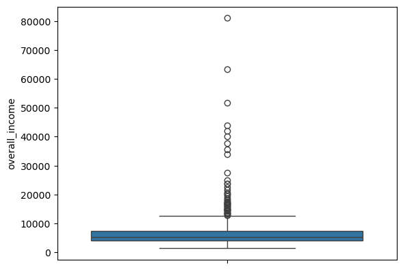

```python
sns.boxplot(df["overall_income"])
plt.show()
```

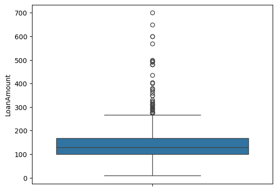

```python
sns.boxplot(df["LoanAmount"])
plt.show()
```

**skewness is only meaningful for numerical (continous or count) variables**

```python
df[continous].skew()   # right skewed
```

```
overall_income    5.633449
LoanAmount        2.677552
dtype: float64
```

```python
df.duplicated().sum()
```

```
0
```

# Data Cleaning

**Treat wrong data**

```python
# in replace use dictionary why it is using .replace because this is not string thats why it used only .replace

df["Dependents"].replace({"3+":3},inplace=True)
```

**check null values sum**

```python
df.isnull().sum()
```

```
Loan_ID              0
Gender              13
Married              3
Dependents          15
Education            0
Self_Employed       32
LoanAmount          22
Loan_Amount_Term    14
Credit_History      50
Property_Area        0
Loan_Status          0
overall_income       0
dtype: int64
```

**Treat missing values(nan)**

- which columns name value are 0 simply left it

**For categorical use MODE**

**For Contionous Use MEAN OR MEDIAN (SALARY,AGE HEIGHT,TEMPRATURE)**

- USE MEAN WHEN DATA IS EVENLY DISTRIBUTED,
- MEDIAN WHEN DATA HAS OUTLIERS OR SKEWED DISRTRIBUTION

**For Count Use MODE (when skewed distribution)**

**For Count Use MEAN (when Normal Distribution )** **COUNT (NUMBER OF ITEMS SOLD, NUMBER OF VISITS) USED MEDIAN (SOMETIME MODE)**

```python
# In discrete we use Mode
# fillna() is fill NaN wuth a fixed Value (Replaces all missing values in the column with 0)

df["Gender"] = df["Gender"].fillna(df["Gender"].mode()[0])
df["Married"] = df["Married"].fillna(df["Married"].mode()[0])

# Discrete count
df["Dependents"] = df["Dependents"].fillna(df["Dependents"].mode()[0])
df["Self_Employed"] = df["Self_Employed"].fillna(df["Self_Employed"].mode()[0])

# LoanAmount, Loan_Amount_Term, Credit_History this risk factor thats why we use dropna()
# dropna() used for Remove rows with any missing values (Delets all rows that contain at least one NaN values)

df = df.dropna()
```

**After Treat the Missing values check missing value is available or not**

```python
df.isnull().sum()
```

```
Loan_ID             0
Gender              0
Married             0
Dependents          0
Education           0
Self_Employed       0
LoanAmount          0
Loan_Amount_Term    0
Credit_History      0
Property_Area       0
Loan_Status         0
overall_income      0
dtype: int64
```

**Treat wrong data type**

```python
df["Dependents"] = df["Dependents"].astype("int")
df["Loan_Amount_Term"] = df["Loan_Amount_Term"].astype("int")
```

**Treat the Outliers**

```python
# Retrain the outliers (Keep them as it is)  this is genuine data
```

**Drop the unimportant column**

```python
df.drop(columns = ["Loan_ID"],inplace = True)   ## Drop are used thats why it shows error
```

**Treat the Duplicate**

# To check duplicate

df.duplicated().sum()

```python
# There is no Duplicate
```

```python
df  # This is our Clean data
```

|  | Gender | Married | Dependents | Education | Self_Employed | LoanAmount | Loan_Amount_Term | Credit_History | Property_Area | Loan_Status | overall_income |
| --- | --- | --- | --- | --- | --- | --- | --- | --- | --- | --- | --- |
| 1 | Male | Yes | 1 | Graduate | No | 128.0 | 360 | Yes | Rural | N | 6091.0 |
| 2 | Male | Yes | 0 | Graduate | Yes | 66.0 | 360 | Yes | Urban | Y | 3000.0 |
| 3 | Male | Yes | 0 | Not Graduate | No | 120.0 | 360 | Yes | Urban | Y | 4941.0 |
| 4 | Male | No | 0 | Graduate | No | 141.0 | 360 | Yes | Urban | Y | 6000.0 |
| 5 | Male | Yes | 2 | Graduate | Yes | 267.0 | 360 | Yes | Urban | Y | 9613.0 |
| ... | ... | ... | ... | ... | ... | ... | ... | ... | ... | ... | ... |
| 609 | Female | No | 0 | Graduate | No | 71.0 | 360 | Yes | Rural | Y | 2900.0 |
| 610 | Male | Yes | 3 | Graduate | No | 40.0 | 180 | Yes | Rural | Y | 4106.0 |
| 611 | Male | Yes | 1 | Graduate | No | 253.0 | 360 | Yes | Urban | Y | 8312.0 |
| 612 | Male | Yes | 2 | Graduate | No | 187.0 | 360 | Yes | Urban | Y | 7583.0 |
| 613 | Female | No | 0 | Graduate | Yes | 133.0 | 360 | No | Semiurban | N | 4583.0 |

529 rows × 11 columns

# Export DataFrames to excel workbook

- After cleaned data you can used in PowerBI or Tableau

```python
df.to_excel("Home_Loan_cleaned_data.xlsx",index=False)
```

# Data Analysis

- Measures + Plots
- Univariate, Bivariate, Multivariate

**Applying various questions or logics on dataset**

**Univariate Measures**

- Categorical = .value_counts()
- Continous = .describe()

```python
df["Gender"].value_counts()
```

```
Gender
Male      434
Female     95
Name: count, dtype: int64
```

```python
df["Married"].value_counts()
```

```
Married
Yes    341
No     188
Name: count, dtype: int64
```

```python
df["Dependents"].value_counts()
```

```
Dependents
0    307
2     92
1     85
3     45
Name: count, dtype: int64
```

```python
df["Education"].value_counts()
```

```
Education
Graduate        421
Not Graduate    108
Name: count, dtype: int64
```

```python
df["Self_Employed"].value_counts()
```

```
Self_Employed
No     459
Yes     70
Name: count, dtype: int64
```

```python
df["LoanAmount"].describe()  # To check Average, Minimum, Maximum Loan Amount
```

```
count    529.000000
mean     145.852552
std       84.108409
min        9.000000
25%      100.000000
50%      128.000000
75%      167.000000
max      700.000000
Name: LoanAmount, dtype: float64
```

```python
df["Loan_Amount_Term"].value_counts()
```

```
Loan_Amount_Term
360    452
180     41
480     14
300     10
120      3
84       3
60       2
240      2
36       2
Name: count, dtype: int64
```

```python
df["Credit_History"].value_counts()
```

```
Credit_History
Yes    450
No      79
Name: count, dtype: int64
```

```python
df["Property_Area"].value_counts()
```

```
Property_Area
Semiurban    209
Urban        165
Rural        155
Name: count, dtype: int64
```

```python
df["Loan_Status"].value_counts()
```

```
Loan_Status
Y    366
N    163
Name: count, dtype: int64
```

```python
df["overall_income"].describe()
```

```
count      529.000000
mean      7050.217240
std       6589.393544
min       1442.000000
25%       4166.000000
50%       5332.000000
75%       7542.000000
max      81000.000000
Name: overall_income, dtype: float64
```

**Bivariate Measures**

- crosstab (2 discrete variable)
- correlation (Continuous + Continuous)
- groupby (1 discrete + 1 continous)

```python
pd.crosstab(df["Gender"],df["Loan_Status"],margins = True)
```

| Loan_Status Gender | N | Y | All |
| --- | --- | --- | --- |
| Female | 34 | 61 | 95 |
| Male | 129 | 305 | 434 |
| All | 163 | 366 | 529 |

```python
# percentage

pd.crosstab(df["Gender"],df["Loan_Status"],margins = True,normalize = True)   # normalize = True means /len(df)
```

| Loan_Status Gender | N | Y | All |
| --- | --- | --- | --- |
| Female | 0.064272 | 0.115312 | 0.179584 |
| Male | 0.243856 | 0.576560 | 0.820416 |
| All | 0.308129 | 0.691871 | 1.000000 |

```python
#To check Mean

df.groupby("Loan_Status")["LoanAmount"].describe().T  # when you use .groupby() you use .describe()

# .T (Transpose) means Column wise
```

| Loan_Status | N | Y |
| --- | --- | --- |
| count | 163.000000 | 366.000000 |
| mean | 150.466258 | 143.797814 |
| std | 87.048112 | 82.804292 |
| min | 9.000000 | 17.000000 |
| 25% | 100.000000 | 100.250000 |
| 50% | 128.000000 | 128.000000 |
| 75% | 173.000000 | 161.750000 |
| max | 570.000000 | 700.000000 |

```python
df.groupby("Loan_Status")["overall_income"].describe().T
```

| Loan_Status | N | Y |
| --- | --- | --- |
| count | 163.000000 | 366.000000 |
| mean | 7274.269939 | 6950.434208 |
| std | 7796.001701 | 5983.541784 |
| min | 1442.000000 | 1963.000000 |
| 25% | 4087.500000 | 4188.750000 |
| 50% | 5230.000000 | 5416.500000 |
| 75% | 7491.000000 | 7548.000000 |
| max | 81000.000000 | 63337.000000 |

```python
pd.crosstab(df["Credit_History"],df["Loan_Status"],margins = True,normalize = True)
```

| Loan_Status Credit_History | N | Y | All |
| --- | --- | --- | --- |
| No | 0.136106 | 0.013233 | 0.149338 |
| Yes | 0.172023 | 0.678639 | 0.850662 |
| All | 0.308129 | 0.691871 | 1.000000 |

**Multivariate Measures**

- correlation (All Continuous variable) Ex = df[['Age', 'Heart rate', 'Blood sugar']].corr()
- crosstab (All discrete variable) Ex = pd.crosstab([df['Gender'], df['Region']], df['Purchased'],margins = True,normalize = True) **OR** pd.crosstab([df['Gender'], df['Region']], [df['Purchased'], df['Channel']])
- groupby (2 discrete + 1 continous) Ex = df.groupby(["Gender","Result"])["Systolic blood pressure"].describe().T

# Hist Plot

**1 continous**

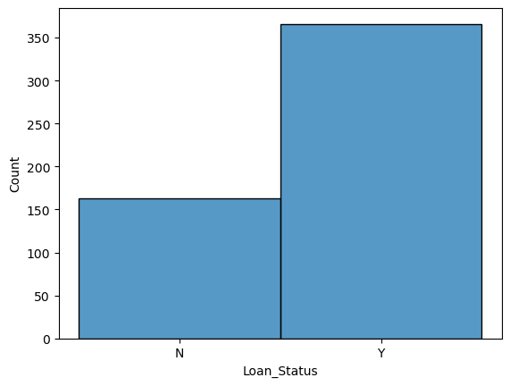

```python
sns.histplot(df["Loan_Status"],bins = 10)
plt.show()
```

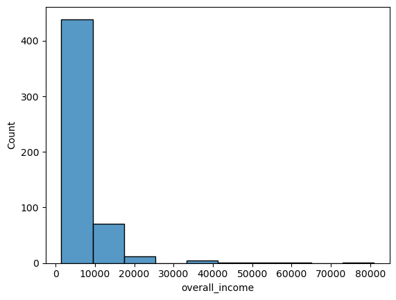

```python
sns.histplot(df["overall_income"],bins = 10)
plt.show()
```

# Kde Plot

**1 continous**

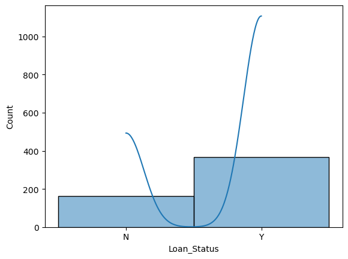

```python
sns.histplot(df["Loan_Status"],bins = 10,kde = True)   # bins = 10 means 10 Interval
plt.show()
```

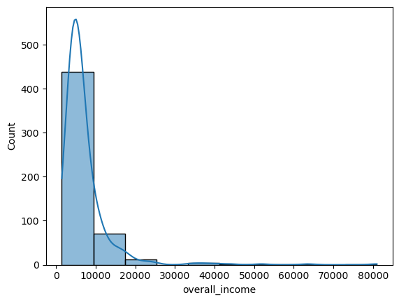

```python
sns.histplot(df["overall_income"],bins = 10,kde = True)
plt.show()
```

# Scatter Plot

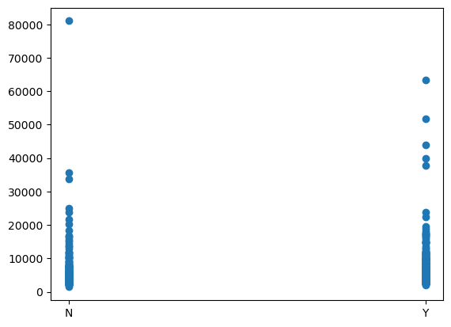

```python
plt.scatter(x=df["Loan_Status"],y=df["overall_income"])
plt.show()
```

# Joint Plot

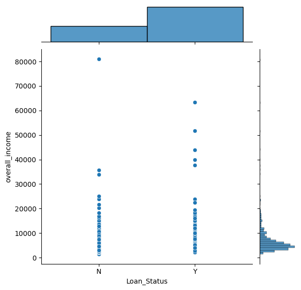

```python
sns.jointplot(x="Loan_Status",y="overall_income",data=df)
plt.show()
```

# Pair Plot

**>2 continous**

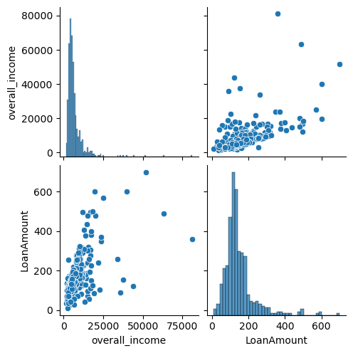

```python
sns.pairplot(df,vars=continous)
plt.show()
```

# Pie plot

**1 discrete**

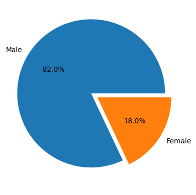

```python
plt.pie(x=df["Gender"].value_counts(),
        labels = df["Gender"].value_counts().index.tolist(),autopct = "%0.1f%%",explode=[0.1,0])
plt.show()
```

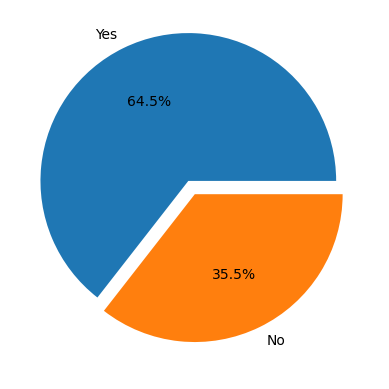

```python
plt.pie(x=df["Married"].value_counts(),
        labels = df["Married"].value_counts().index.tolist(),autopct = "%0.1f%%",explode=[0.1,0])
plt.show()
```

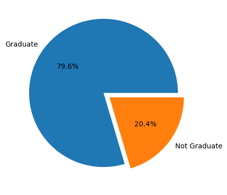

```python
plt.pie(x=df["Education"].value_counts(),
        labels = df["Education"].value_counts().index.tolist(),autopct = "%0.1f%%",explode=[0.1,0])
plt.show()
```

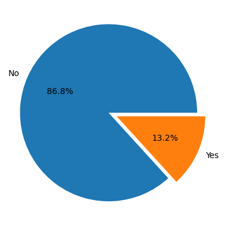

```python
plt.pie(x=df["Self_Employed"].value_counts(),
        labels = df["Self_Employed"].value_counts().index.tolist(),autopct = "%0.1f%%",explode=[0.1,0])
plt.show()
```

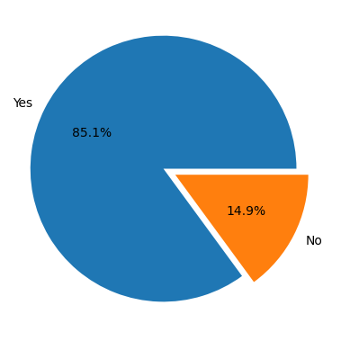

```python
plt.pie(x=df["Credit_History"].value_counts(),
        labels = df["Credit_History"].value_counts().index.tolist(),autopct = "%0.1f%%",explode=[0.1,0])
plt.show()
```

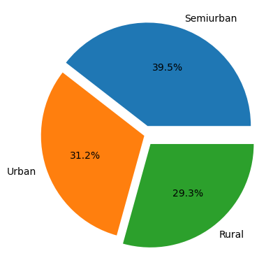

```python
plt.pie(x=df["Property_Area"].value_counts(),
        labels = df["Property_Area"].value_counts().index.tolist(),autopct = "%0.1f%%",explode=[0.1,0,0.1])
plt.show()
```

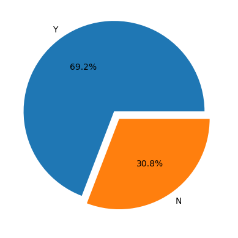

```python
plt.pie(x=df["Loan_Status"].value_counts(),
        labels = df["Loan_Status"].value_counts().index.tolist(),autopct = "%0.1f%%",explode=[0.1,0])
plt.show()
```

# Count Plot

**1 Discrete**

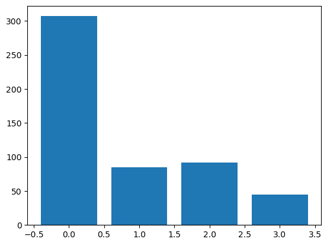

```python
plt.bar(df["Dependents"].value_counts().index,df["Dependents"].value_counts())
plt.show()
```

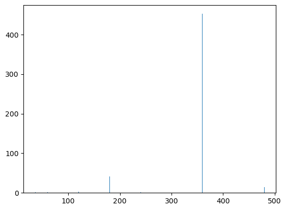

```python
plt.bar(df["Loan_Amount_Term"].value_counts().index,df["Loan_Amount_Term"].value_counts())
plt.show()
```

# Bar plot

**1 Discrete + 1 continous**

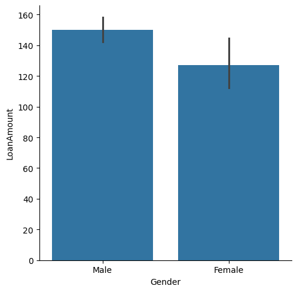

```python
sns.catplot(x="Gender",y="LoanAmount",data=df,kind="bar")
plt.show()
```

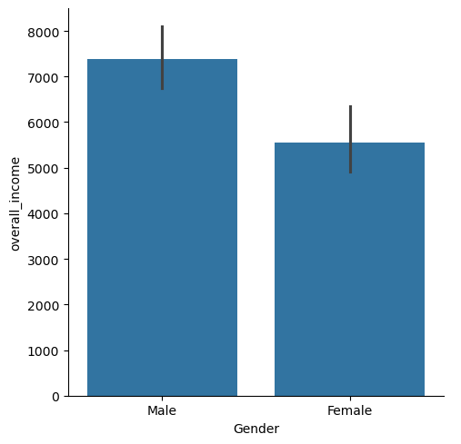

```python
sns.catplot(x="Gender",y="overall_income",data=df,kind="bar")
plt.show()
```

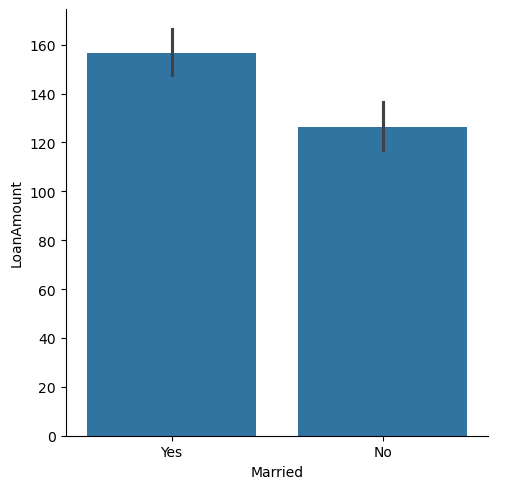

```python
sns.catplot(x="Married",y="LoanAmount",data=df,kind="bar")
plt.show()
```

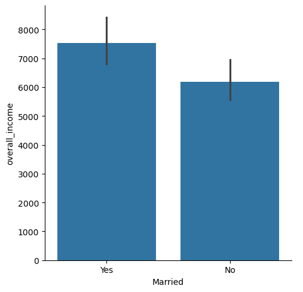

```python
sns.catplot(x="Married",y="overall_income",data=df,kind="bar")
plt.show()
```

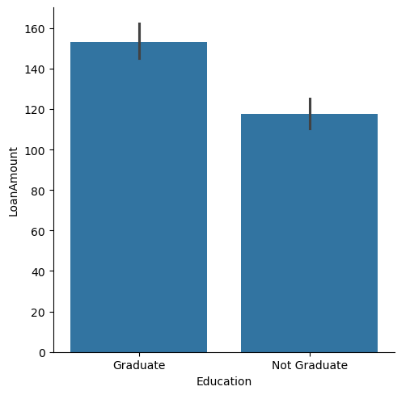

```python
sns.catplot(x="Education",y="LoanAmount",data=df,kind="bar")
plt.show()
```

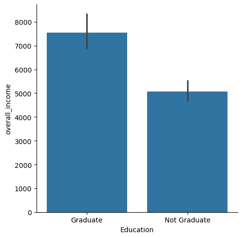

```python
sns.catplot(x="Education",y="overall_income",data=df,kind="bar")
plt.show()
```

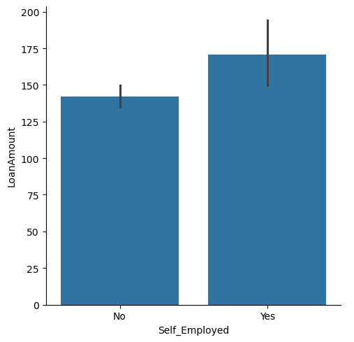

```python
sns.catplot(x="Self_Employed",y="LoanAmount",data=df,kind="bar")
plt.show()
```

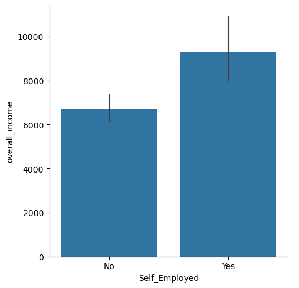

```python
sns.catplot(x="Self_Employed",y="overall_income",data=df,kind="bar")
plt.show()
```

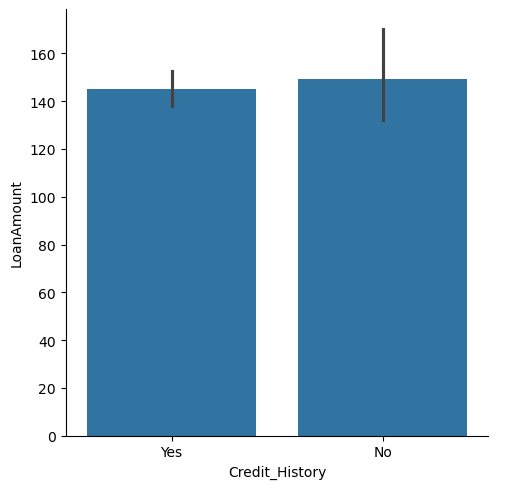

```python
sns.catplot(x="Credit_History",y="LoanAmount",data=df,kind="bar")
plt.show()
```